# Modeling & Simulating Hourly Temperature

This example demonstrates fitting a non-linear temperature model to hourly dry bulb temperatures recorded in the New England region. The temperature series is modeled as a sum of two compoments, a deterministic non-linear function that explains the seasonal or expected temperature for a given hour in a given year and a stochastic component that explains deviations of actual temperature from average values.

Table of Contents

Import Data Seasonal Component (Deterministic) Visualize Model Accuracy Analyze Serial Correlation in Residuals Modeling the Stochastic Component with a ARIMX model Analyze Residuals of Regression for Serial Correlation Model Estimate Summary of model

## Import Data

The data set is loaded from a previously created MAT-file. It consist of a vector of serial dates and the corresponding historical recorded temperature.

```matlab
clear
load Data\elecPrices.mat

% select data of interest
Temp = elecPrices(:,{'Dew_Point','Dry_Bulb'});
tail(Temp)
```

ans = 8×2 timetable

|  | Dew_Point | Dry_Bulb |
| --- | --- | --- |
| 1 11/30/2018 | 29 | 36 |
| 2 11/30/2018 | 30 | 35 |
| 3 11/30/2018 | 30 | 35 |
| 4 11/30/2018 | 30 | 35 |
| 5 11/30/2018 | 30 | 35 |
| 6 11/30/2018 | 29 | 34 |
| 7 11/30/2018 | 29 | 34 |
| 8 11/30/2018 | 29 | 33 |

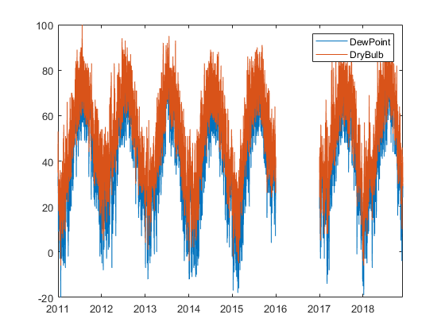

```matlab
plot(Temp.Date,[Temp.Dew_Point,Temp.Dry_Bulb])
legend('DewPoint','DryBulb')
```

Note the missing year of temperature data from 2016 to 2017. We will need to account for this during the estimation of the model.

## Seasonal Component (Deterministic)

The deterministic or expected temperature component is modeled with a sum of sines model, motivated by the physical nature of temperature and periodicities observed in the data. Curve Fitting toolbox is used to estimate the parameters of the model. The Statistics Toolbox function NLINFIT can also be used to estimate the model parameters.

```matlab
% Compute mean (yearly average) and remove it from the series
validIndices = find(~isnan(Temp.Dry_Bulb));
m = mean(Temp.Dry_Bulb(validIndices))
```

m = 50.8951

```matlab
drybulb0 = Temp.Dry_Bulb(validIndices) - m;

% Fit double-sine model
numericDates = datenum(Temp.Date(validIndices));
model = fit(numericDates, drybulb0, 'sin2')
```

model =

General model Sin2: model(x) = a1*sin(b1*x+c1) + a2*sin(b2*x+c2) Coefficients (with 95% confidence bounds): a1 = 22.77 (22.66, 22.87) b1 = 0.01734 (0.01733, 0.01734) c1 = -1559 (-1563, -1555) a2 = 0.01598 (-0.08931, 0.1213) b2 = 5.488 (5.48, 5.495) c2 = 2.264 (-5621, 5626)

## Visualize Model Accuracy

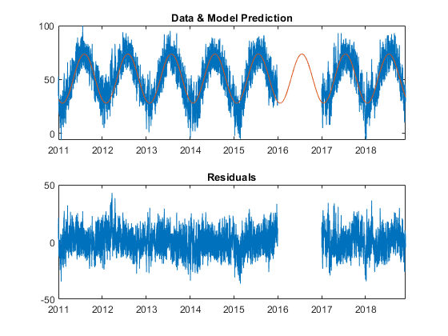

```matlab
Temp.pred = model(datenum(Temp.Date)) + m;
res = Temp.Dry_Bulb - Temp.pred;
subplot(2,1,1)
plot(Temp.Date,[Temp.Dry_Bulb Temp.pred])
title('Data & Model Prediction')

subplot(2,1,2)
plot(Temp.Date, res)
title('Residuals')
```

```matlab
disp(['Mean Absolute Error: ' num2str(mean(abs(res))) ' degrees F']);
```

Mean Absolute Error: NaN degrees F

## Analyze Serial Correlation in Residuals

One of the features apparent in the above plot is that the residuals are serially correlated. This is expected as above average temperatures are likely to follow above average temperatures. This serial correlation can be explicitly measured. Here, the functions AUTOCORR and PARCORR are used to display the autocorrelation and partial autocorrelation in the series.

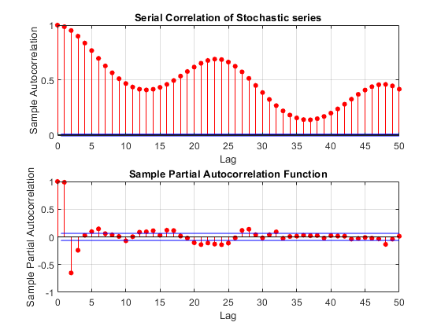

```matlab
figure;
subplot(2,1,1);
autocorr(res,50);
title('Serial Correlation of Stochastic series');
subplot(2,1,2);
parcorr(res(1:1000),50);
```

## Modeling the Stochastic Component with a ARIMX model

One could choose to model the random component a mean reverting drift SDE. However, because of the seasonality, we will use an auto-regressive model with seasonal lags.

```matlab
lags = [1 2 3 4 23 24 25 47 48 49];
%% Estimate an ARIMAX Model of time series Dry_Bulb with exogenouse factor the avergage temperature (pred)
ARIMAX_Dry_Bulb = arima('Constant',NaN,'ARLags',lags,'D',0,'MALags',[],'Distribution','Gaussian');
validIndices = find(~any(isnan([Temp.Dry_Bulb,Temp.pred]),2));
preSampleNumber = ARIMAX_Dry_Bulb.P;
preSampleResponse = Temp.Dry_Bulb(validIndices(1:preSampleNumber));
estimateResponse = Temp.Dry_Bulb(validIndices(preSampleNumber+1:end));
pred = Temp.pred(validIndices);
ARIMAX_Dry_Bulb = estimate(ARIMAX_Dry_Bulb,estimateResponse,'Y0',preSampleResponse,'X',pred,'Display','off');
summarize(ARIMAX_Dry_Bulb)
```

**ARIMAX(49,0,0) Model (Gaussian Distribution)** Effective Sample Size: 60551 Number of Estimated Parameters: 13 LogLikelihood: -85648.4 AIC: 171323 BIC: 171440 **Value** **StandardError** **TStatistic** **PValue** **__________** **_____________** **__________** **___________** **Constant** -0.0081649 0.013797 -0.5918 0.55399 **AR{1}** 1.317 0.003305 398.5 0 **AR{2}** -0.15082 0.0056532 -26.679 8.239e-157 **AR{3}** -0.20443 0.006037 -33.863 2.334e-251 **AR{4}** 0.01574 0.0034436 4.571 4.8547e-06 **AR{23}** 0.1394 0.0035702 39.046 0 **AR{24}** 0.0028747 0.0062495 0.45999 0.64552 **AR{25}** -0.14879 0.0036798 -40.435 0 **AR{47}** 0.091294 0.0037671 24.235 9.5575e-130 **AR{48}** 0.006776 0.0065123 1.0405 0.29811 **AR{49}** -0.088026 0.003765 -23.38 6.8468e-121 **Beta(1)** 0.019089 0.00059513 32.075 9.7386e-226 **Variance** 0.99124 0.004224 234.67 0

## Analyze Residuals of Regression for Serial Correlation

The residuals from the regression should now be mostly serially uncorrelated.

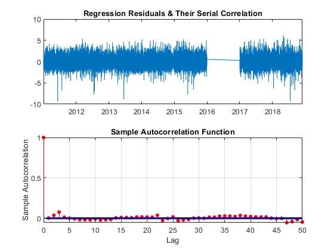

```matlab
res = infer(ARIMAX_Dry_Bulb,estimateResponse,'Y0',preSampleResponse,'X',pred);
figure;
subplot(2,1,1);
dates = Temp.Date(validIndices);
plot(dates(preSampleNumber+1:end), res);
title('Regression Residuals & Their Serial Correlation');
subplot(2,1,2);
autocorr(res,50);
```

## Model Estimate

Put the different components together to see how the model fits the data. We will need to forecast the period for 2016 first using the data up to 2016.

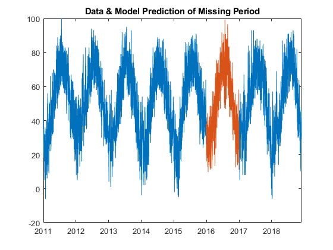

```matlab
Indicies2016 = find(ismissing(Temp.Dry_Bulb));
preSampleIndicies = (Indicies2016(1)-preSampleNumber):Indicies2016(1)-1;
Temp2016= simulate(ARIMAX_Dry_Bulb,length(Indicies2016),'Y0',Temp.Dry_Bulb(preSampleIndicies),'X',Temp.pred(preSampleIndicies(1):Indicies2016(end)));
figure
plot(Temp.Date,Temp.Dry_Bulb, Temp.Date(Indicies2016), Temp2016)
title('Data & Model Prediction of Missing Period')
```

Now add in a simulation of the entire series by putting the Temp2016 data into the Temp timetable

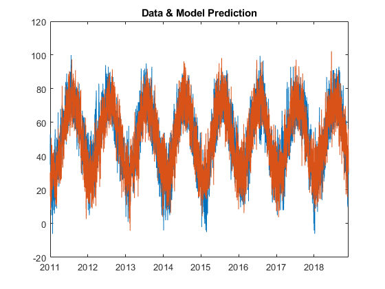

```matlab
Temp.Dry_Bulb(Indicies2016) = Temp2016;
simTemp = simulate(ARIMAX_Dry_Bulb,length(Temp.Dry_Bulb),'Y0',Temp.Dry_Bulb(1:preSampleNumber),'X',Temp.pred);

figure
plot(Temp.Date,[Temp.Dry_Bulb, simTemp])
title('Data & Model Prediction')
```

## Summary of model

The temperature model can now be defined by,

- The mean temperature "m"
- The sinusoidal model "model"
- ARIMAX parameters and lags

```matlab
tempModel = struct('m', m, 'sinmodel', model, 'reglags', lags, 'arimax', ARIMAX_Dry_Bulb,'lastDate',Temp.Date(end),'Freq','hourly');
save SavedModels\TemperatureModel.mat -struct tempModel
```